# Netflix Business Case: Data Exploration and Visualisation

## Introduction

This project analyzes Netflix’s content catalog to identify patterns in the type of content available on the platform and generate business insights that can help Netflix make better decisions about **what kind of shows or movies to produce** and **how to grow its business across different countries**.

Netflix is one of the world’s most popular media and video streaming platforms. As of mid-2021, it had over **222 million subscribers globally** and offered a large catalog of movies and TV shows. The dataset used in this case study contains information about titles available on Netflix, including details such as:

- show type
- title
- director
- cast
- country
- date added
- release year
- rating
- duration
- genre
- description

## Business Problem

The goal of this case study is to analyze Netflix’s catalog and generate data-driven insights that can help answer questions such as:

- What type of content is available in different countries?
- How has the number of movies released per year changed over time?
- How do TV shows compare with movies on the platform?
- What might be the best time to launch a TV show?
- Which actors and directors appear most often in different types of content?
- Has Netflix shifted focus toward TV shows in recent years?
- What patterns in content distribution can help Netflix grow in international markets?

## Objective of the Analysis

The main objectives of this project are:

1. Understand the structure and quality of the dataset
2. Perform data cleaning and preprocessing
3. Conduct non-graphical and visual exploratory data analysis
4. Identify important content trends across type, country, release year, rating, genre, actors, and directors
5. Generate business insights from the observed patterns
6. Provide simple and actionable recommendations for Netflix leadership

## Dataset Description

The dataset contains the following columns:

- **show_id**: Unique ID for every movie or TV show
- **type**: Whether the title is a Movie or TV Show
- **title**: Name of the movie or TV show
- **director**: Director of the title
- **cast**: Actors involved in the title
- **country**: Country where the content was produced
- **date_added**: Date the content was added to Netflix
- **release_year**: Actual release year of the content
- **rating**: TV/content rating
- **duration**: Duration in minutes or number of seasons
- **listed_in**: Genre/category of the content
- **description**: Summary description of the title

## Approach

To solve this business problem, this notebook will follow these steps:

1. Import libraries and load the dataset
2. Understand the shape, columns, data types, and missing values
3. Perform preprocessing and feature cleanup
4. Conduct non-graphical analysis
5. Perform univariate and bivariate visual analysis
6. Check missing values and outliers
7. Summarize key business insights
8. Provide final recommendations for Netflix

## Evaluation-Focused Note

This notebook is designed as a business-facing case study. The analysis will focus not only on technical exploration, but also on clear interpretation, practical insights, and recommendations that can be understood by business stakeholders without relying on heavy technical jargon.

```python
# Import Libraries and Test Setup
import warnings
warnings.filterwarnings("ignore")

import numpy as np
import pandas as pd
import matplotlib.pyplot as plt
import seaborn as sns

pd.set_option('display.max_columns', None)
pd.set_option('display.max_rows', 200)

print("All libraries imported successfully.")
```

```
All libraries imported successfully.
```

```python
# Load Dataset and Preview
df = pd.read_csv("netflix.csv")
df.head()
```

|  | show_id | type | title | director | cast | country | date_added | release_year | rating | duration | listed_in | description |
| --- | --- | --- | --- | --- | --- | --- | --- | --- | --- | --- | --- | --- |
| 0 | s1 | Movie | Dick Johnson Is Dead | Kirsten Johnson | NaN | United States | September 25, 2021 | 2020 | PG-13 | 90 min | Documentaries | As her father nears the end of his life, filmm... |
| 1 | s2 | TV Show | Blood & Water | NaN | Ama Qamata, Khosi Ngema, Gail Mabalane, Thaban... | South Africa | September 24, 2021 | 2021 | TV-MA | 2 Seasons | International TV Shows, TV Dramas, TV Mysteries | After crossing paths at a party, a Cape Town t... |
| 2 | s3 | TV Show | Ganglands | Julien Leclercq | Sami Bouajila, Tracy Gotoas, Samuel Jouy, Nabi... | NaN | September 24, 2021 | 2021 | TV-MA | 1 Season | Crime TV Shows, International TV Shows, TV Act... | To protect his family from a powerful drug lor... |
| 3 | s4 | TV Show | Jailbirds New Orleans | NaN | NaN | NaN | September 24, 2021 | 2021 | TV-MA | 1 Season | Docuseries, Reality TV | Feuds, flirtations and toilet talk go down amo... |
| 4 | s5 | TV Show | Kota Factory | NaN | Mayur More, Jitendra Kumar, Ranjan Raj, Alam K... | India | September 24, 2021 | 2021 | TV-MA | 2 Seasons | International TV Shows, Romantic TV Shows, TV ... | In a city of coaching centers known to train I... |

```python
# Shape and Column Names
print("Shape of dataset:", df.shape)
print("\nColumn names:")
print(df.columns.tolist())
```

```
Shape of dataset: (8807, 12)

Column names:
['show_id', 'type', 'title', 'director', 'cast', 'country', 'date_added', 'release_year', 'rating', 'duration', 'listed_in', 'description']
```

```python
# A Quick Data Overview
df.info()
```

```
<class 'pandas.core.frame.DataFrame'>
RangeIndex: 8807 entries, 0 to 8806
Data columns (total 12 columns):
 #   Column        Non-Null Count  Dtype
---  ------        --------------  -----
 0   show_id       8807 non-null   object
 1   type          8807 non-null   object
 2   title         8807 non-null   object
 3   director      6173 non-null   object
 4   cast          7982 non-null   object
 5   country       7976 non-null   object
 6   date_added    8797 non-null   object
 7   release_year  8807 non-null   int64
 8   rating        8803 non-null   object
 9   duration      8804 non-null   object
 10  listed_in     8807 non-null   object
 11  description   8807 non-null   object
dtypes: int64(1), object(11)
memory usage: 825.8+ KB
```

## Initial Observations

The dataset has been loaded successfully and contains **8,807 rows** and **12 columns**.

### Structure of the dataset

- The dataset includes information about Netflix titles such as:
  - content type
  - title
  - director
  - cast
  - country
  - date added
  - release year
  - rating
  - duration
  - genre
  - description

### Data type observations

- Most columns are currently stored as **string/object** type
- Only **`release_year`** is currently in numeric format (`int64`)
- Columns such as **`date_added`** will need to be converted into proper datetime format during preprocessing
- Some categorical columns may later be converted to **category** type for cleaner analysis

### Missing value observations

There are visible missing values in multiple columns, especially:

- **director**
- **cast**
- **country**
- **date_added**
- **rating**
- **duration**

This indicates that data cleaning and preprocessing will be an important part of the analysis before moving into non-graphical and visual exploration.

### Next step

The next step is to perform a more detailed data quality check, including:

- missing value analysis
- duplicate row check
- summary statistics
- unique value counts
- data type review and preprocessing preparation

```python
# Missing Values
df.isnull().sum()
```

```
show_id            0
type               0
title              0
director        2634
cast             825
country          831
date_added        10
release_year       0
rating             4
duration           3
listed_in          0
description        0
dtype: int64
```

```python
# Missing Value Percentage
round((df.isnull().sum()/len(df)*100),2)
```

```
show_id          0.00
type             0.00
title            0.00
director        29.91
cast             9.37
country          9.44
date_added       0.11
release_year     0.00
rating           0.05
duration         0.03
listed_in        0.00
description      0.00
dtype: float64
```

```python
# Duplicate Rows
print("NUmber of Duplicate Rows:", df.duplicated().sum())
```

```
NUmber of Duplicate Rows: 0
```

```python
# Summary Statistics
df.describe(include = 'all').T
```

|  | count | unique | top | freq | mean | std | min | 25% | 50% | 75% | max |
| --- | --- | --- | --- | --- | --- | --- | --- | --- | --- | --- | --- |
| show_id | 8807 | 8807 | s1 | 1 | NaN | NaN | NaN | NaN | NaN | NaN | NaN |
| type | 8807 | 2 | Movie | 6131 | NaN | NaN | NaN | NaN | NaN | NaN | NaN |
| title | 8807 | 8807 | Dick Johnson Is Dead | 1 | NaN | NaN | NaN | NaN | NaN | NaN | NaN |
| director | 6173 | 4528 | Rajiv Chilaka | 19 | NaN | NaN | NaN | NaN | NaN | NaN | NaN |
| cast | 7982 | 7692 | David Attenborough | 19 | NaN | NaN | NaN | NaN | NaN | NaN | NaN |
| country | 7976 | 748 | United States | 2818 | NaN | NaN | NaN | NaN | NaN | NaN | NaN |
| date_added | 8797 | 1767 | January 1, 2020 | 109 | NaN | NaN | NaN | NaN | NaN | NaN | NaN |
| release_year | 8807.0 | NaN | NaN | NaN | 2014.180198 | 8.819312 | 1925.0 | 2013.0 | 2017.0 | 2019.0 | 2021.0 |
| rating | 8803 | 17 | TV-MA | 3207 | NaN | NaN | NaN | NaN | NaN | NaN | NaN |
| duration | 8804 | 220 | 1 Season | 1793 | NaN | NaN | NaN | NaN | NaN | NaN | NaN |
| listed_in | 8807 | 514 | Dramas, International Movies | 362 | NaN | NaN | NaN | NaN | NaN | NaN | NaN |
| description | 8807 | 8775 | Paranormal activity at a lush, abandoned prope... | 4 | NaN | NaN | NaN | NaN | NaN | NaN | NaN |

## Observations from Data Quality Checks and Summary Statistics

Based on the initial exploration, the dataset contains **8,807 titles** and **12 columns**, which provides a reasonably large sample for analyzing Netflix’s content catalog.

### 1. Dataset structure

- The dataset includes both **movies** and **TV shows**
- There are **no duplicate rows**, which means we do not need to perform duplicate removal at this stage
- Most columns are stored as **object/string** type, while `release_year` is the main numeric column currently available for direct quantitative analysis

### 2. Missing value observations

The dataset contains missing values in a few important columns:

- **director** has the highest missingness: **2,634 missing values (~29.91%)**
- **country** has **831 missing values (~9.44%)**
- **cast** has **825 missing values (~9.37%)**
- **date_added**, **rating**, and **duration** have only a very small number of missing values

#### Interpretation

The high percentage of missing values in `director` suggests that this column may be incomplete for a significant portion of titles, especially for certain content categories or regions. The missing values in `country` and `cast` are also important because both columns are directly relevant to business questions related to international expansion and talent analysis.

### 3. Summary-level observations

- `type` contains only **2 categories**, which confirms that the catalog is split into **Movies** and **TV Shows**
- `show_id` and `title` appear to behave like identifier fields
- `country`, `director`, `cast`, and `listed_in` have high-cardinality text values, which indicates that preprocessing and unnesting will be required before detailed analysis
- `release_year` ranges from **1925 to 2021**, showing that Netflix contains both older titles and very recent releases
- The median release year is relatively recent, suggesting that much of the catalog is concentrated in modern content
- The most common content rating appears to be **TV-MA**
- The `duration` column includes mixed formats such as minutes for movies and seasons for TV shows, so this feature will need to be separated into cleaner components before analysis

### 4. Key preprocessing implications

Before moving into deeper visual and business analysis, the following preprocessing steps will be necessary:

- convert `date_added` into datetime format
- clean and split the `duration` column
- unnest columns such as `country`, `director`, `cast`, and `listed_in`
- review how missing values should be handled for key business variables

### 5. Business relevance

These early observations already suggest that the dataset is suitable for business analysis, but it also shows that raw data cannot be interpreted directly without cleaning. In particular, fields related to **country**, **director**, **cast**, and **duration** will play an important role in answering Netflix’s strategic questions around content production, content mix, and international growth.

## Data Cleaning and Preprocessing

Before starting non-graphical and visual analysis, the dataset needs to be cleaned and prepared.

This preprocessing stage focuses on:

- converting date columns into proper datetime format
- extracting useful time-based features
- cleaning the `duration` column
- checking unique values in important categorical columns
- preparing multi-value columns such as `country`, `director`, `cast`, and `listed_in` for deeper analysis

These steps are necessary because several variables are stored as raw text and cannot be analyzed properly in their current form.

```python
# Create a copy of the original dataset for preprocessing
df_clean = df.copy()

print("Working copy created successfully.")
```

```
Working copy created successfully.
```

```python
# Convert date_added to datetime
df_clean['date_added'] = pd.to_datetime(df_clean['date_added'], errors='coerce')

df_clean[['date_added']].head()
```

|  | date_added |
| --- | --- |
| 0 | 2021-09-25 |
| 1 | 2021-09-24 |
| 2 | 2021-09-24 |
| 3 | 2021-09-24 |
| 4 | 2021-09-24 |

```python
# Extract year_added and month_added from date_added
df_clean['year_added'] = df_clean['date_added'].dt.year
df_clean['month_added'] = df_clean['date_added'].dt.month_name()

df_clean[['date_added', 'year_added', 'month_added']].head()
```

|  | date_added | year_added | month_added |
| --- | --- | --- | --- |
| 0 | 2021-09-25 | 2021.0 | September |
| 1 | 2021-09-24 | 2021.0 | September |
| 2 | 2021-09-24 | 2021.0 | September |
| 3 | 2021-09-24 | 2021.0 | September |
| 4 | 2021-09-24 | 2021.0 | September |

```python
# Inspect unique examples from the duration column
df_clean['duration'].dropna().sample(10, random_state=42)
```

```
95      3 Seasons
3349       97 min
4687     1 Season
2816     1 Season
360       125 min
5516      106 min
4011       98 min
6830      107 min
3412      112 min
2465      116 min
Name: duration, dtype: object
```

```python
# Split duration into numeric value and unit
df_clean[['duration_int', 'duration_type']] = df_clean['duration'].str.extract(r'(\d+)\s*(\w+)')

df_clean['duration_int'] = pd.to_numeric(df_clean['duration_int'], errors='coerce')

df_clean[['duration', 'duration_int', 'duration_type']].head(10)
```

|  | duration | duration_int | duration_type |
| --- | --- | --- | --- |
| 0 | 90 min | 90.0 | min |
| 1 | 2 Seasons | 2.0 | Seasons |
| 2 | 1 Season | 1.0 | Season |
| 3 | 1 Season | 1.0 | Season |
| 4 | 2 Seasons | 2.0 | Seasons |
| 5 | 1 Season | 1.0 | Season |
| 6 | 91 min | 91.0 | min |
| 7 | 125 min | 125.0 | min |
| 8 | 9 Seasons | 9.0 | Seasons |
| 9 | 104 min | 104.0 | min |

```python
# Check the unique duration types after splitting
df_clean['duration_type'].value_counts(dropna=False)
```

```
duration_type
min        6128
Season     1793
Seasons     883
NaN           3
Name: count, dtype: int64
```

```python
# Standardize duration_type values
df_clean['duration_type'] = df_clean['duration_type'].replace({
    'Season': 'Seasons',
    'min': 'Minutes'
})

df_clean['duration_type'].value_counts(dropna=False)
```

```
duration_type
Minutes    6128
Seasons    2676
NaN           3
Name: count, dtype: int64
```

```python
# Check unique counts for important categorical columns
categorical_cols = ['type', 'rating', 'country', 'director', 'cast', 'listed_in']

for col in categorical_cols:
    print(f"{col}: {df_clean[col].nunique(dropna=True)} unique values")
```

```
type: 2 unique values
rating: 17 unique values
country: 748 unique values
director: 4528 unique values
cast: 7692 unique values
listed_in: 514 unique values
```

```python
# Convert suitable columns to category type
category_cols = ['type', 'rating', 'duration_type', 'month_added']

for col in category_cols:
    df_clean[col] = df_clean[col].astype('category')

df_clean[category_cols].dtypes
```

```
type             category
rating           category
duration_type    category
month_added      category
dtype: object
```

```python
# Check updated data types
df_clean.info()
```

```
<class 'pandas.core.frame.DataFrame'>
RangeIndex: 8807 entries, 0 to 8806
Data columns (total 16 columns):
 #   Column         Non-Null Count  Dtype
---  ------         --------------  -----
 0   show_id        8807 non-null   object
 1   type           8807 non-null   category
 2   title          8807 non-null   object
 3   director       6173 non-null   object
 4   cast           7982 non-null   object
 5   country        7976 non-null   object
 6   date_added     8709 non-null   datetime64[ns]
 7   release_year   8807 non-null   int64
 8   rating         8803 non-null   category
 9   duration       8804 non-null   object
 10  listed_in      8807 non-null   object
 11  description    8807 non-null   object
 12  year_added     8709 non-null   float64
 13  month_added    8709 non-null   category
 14  duration_int   8804 non-null   float64
 15  duration_type  8804 non-null   category
dtypes: category(4), datetime64[ns](1), float64(2), int64(1), object(8)
memory usage: 861.5+ KB
```

## Observations from Preprocessing

Several important preprocessing steps were completed to make the dataset ready for deeper exploratory and business analysis.

### 1. Date conversion and feature extraction

- The `date_added` column was successfully converted from string format into **datetime**
- Two additional time-based features were created:
  - `year_added`
  - `month_added`

These new variables will help analyze when content was added to Netflix and identify possible seasonal or yearly platform trends.

### 2. Duration cleaning

- The original `duration` column contained mixed formats:
  - movie durations in **minutes**
  - TV show durations in **seasons**
- To make this column analyzable, it was split into:
  - `duration_int`
  - `duration_type`

After standardization, the dataset shows:

- **6128 titles** with duration measured in **Minutes**
- **2676 titles** with duration measured in **Seasons**
- **3 records** with missing duration information

This confirms that the dataset contains a much larger number of movie-style durations than season-based durations, which is consistent with Netflix having more movies than TV shows.

### 3. Categorical variable review

The number of unique values in some important categorical variables is as follows:

- `type` → **2 unique values**
- `rating` → **17 unique values**
- `country` → **748 unique values**
- `director` → **4528 unique values**
- `cast` → **7692 unique values**
- `listed_in` → **514 unique values**

This shows that `country`, `director`, `cast`, and `listed_in` are **high-cardinality columns**, and these variables will require splitting and unnesting before detailed actor-level, country-level, director-level, or genre-level analysis.

### 4. Data type improvements

The following columns were converted to **category** type for cleaner and more efficient analysis:

- `type`
- `rating`
- `duration_type`
- `month_added`

In addition, the cleaned dataset now contains **16 columns**, compared to the original 12 columns, because of the newly created preprocessing features.

### 5. Why this preprocessing matters

These preprocessing steps were necessary because the raw dataset could not directly support high-quality business analysis. After cleaning, the data is now better structured for answering questions related to:

- movie vs TV show comparisons
- launch timing patterns
- country-wise content distribution
- rating and genre trends
- business recommendations for Netflix content strategy

```python
df_clean[['type', 'duration', 'duration_int', 'duration_type', 'year_added', 'month_added']].head(10)
```

|  | type | duration | duration_int | duration_type | year_added | month_added |
| --- | --- | --- | --- | --- | --- | --- |
| 0 | Movie | 90 min | 90.0 | Minutes | 2021.0 | September |
| 1 | TV Show | 2 Seasons | 2.0 | Seasons | 2021.0 | September |
| 2 | TV Show | 1 Season | 1.0 | Seasons | 2021.0 | September |
| 3 | TV Show | 1 Season | 1.0 | Seasons | 2021.0 | September |
| 4 | TV Show | 2 Seasons | 2.0 | Seasons | 2021.0 | September |
| 5 | TV Show | 1 Season | 1.0 | Seasons | 2021.0 | September |
| 6 | Movie | 91 min | 91.0 | Minutes | 2021.0 | September |
| 7 | Movie | 125 min | 125.0 | Minutes | 2021.0 | September |
| 8 | TV Show | 9 Seasons | 9.0 | Seasons | 2021.0 | September |
| 9 | Movie | 104 min | 104.0 | Minutes | 2021.0 | September |

## Non-Graphical Analysis

After cleaning the data, the next step is to perform non-graphical analysis.

The purpose of this section is to understand the dataset using summary tables, counts, and frequency-based observations before moving into visual analysis.

This section focuses on:

- comparing movies and TV shows
- understanding release year patterns
- identifying the most common ratings
- identifying the most frequent genres, countries, directors, and cast members
- highlighting early business patterns in Netflix’s catalog

```python
# Movies vs TV Shows Count
type_counts = df_clean['type'].value_counts()
type_counts
```

```
type
Movie      6131
TV Show    2676
Name: count, dtype: int64
```

```python
# Percentage Split of Movies vs TV Shows
# Percentage distribution of content types
round(df_clean['type'].value_counts(normalize=True, dropna=False)* 100, 2)
```

```
type
Movie      69.62
TV Show    30.38
Name: proportion, dtype: float64
```

```python
# Release Year Summary
df_clean['release_year'].describe()
```

```
count    8807.000000
mean     2014.180198
std         8.819312
min      1925.000000
25%      2013.000000
50%      2017.000000
75%      2019.000000
max      2021.000000
Name: release_year, dtype: float64
```

```python
# Title added per summary
# Number of titles added to netflix each year
df_clean['year_added'].value_counts().sort_index()
```

```
year_added
2008.0       2
2009.0       2
2010.0       1
2011.0      13
2012.0       3
2013.0      10
2014.0      23
2015.0      73
2016.0     418
2017.0    1164
2018.0    1625
2019.0    1999
2020.0    1878
2021.0    1498
Name: count, dtype: int64
```

```python
# Most common ratings
df_clean['rating'].value_counts()
```

```
rating
TV-MA       3207
TV-14       2160
TV-PG        863
R            799
PG-13        490
TV-Y7        334
TV-Y         307
PG           287
TV-G         220
NR            80
G             41
TV-Y7-FV       6
UR             3
NC-17          3
74 min         1
84 min         1
66 min         1
Name: count, dtype: int64
```

```python
# Top listed_in values (before splitting)
df_clean['listed_in'].value_counts().head(10)
```

```
listed_in
Dramas, International Movies                        362
Documentaries                                       359
Stand-Up Comedy                                     334
Comedies, Dramas, International Movies              274
Dramas, Independent Movies, International Movies    252
Kids' TV                                            220
Children & Family Movies                            215
Children & Family Movies, Comedies                  201
Documentaries, International Movies                 186
Dramas, International Movies, Romantic Movies       180
Name: count, dtype: int64
```

```python
# Top country values (before splitting)
df_clean['country'].value_counts().head(10)
```

```
country
United States     2818
India              972
United Kingdom     419
Japan              245
South Korea        199
Canada             181
Spain              145
France             124
Mexico             110
Egypt              106
Name: count, dtype: int64
```

```python
# Top directors before splitting
df_clean['director'].value_counts().head(10)
```

```
director
Rajiv Chilaka             19
Raúl Campos, Jan Suter    18
Marcus Raboy              16
Suhas Kadav               16
Jay Karas                 14
Cathy Garcia-Molina       13
Martin Scorsese           12
Youssef Chahine           12
Jay Chapman               12
Steven Spielberg          11
Name: count, dtype: int64
```

```python
# Duration summary for movies only
df_clean[df_clean['duration_type'] == 'Minutes']['duration_int'].describe()
```

```
count    6128.000000
mean       99.577187
std        28.290593
min         3.000000
25%        87.000000
50%        98.000000
75%       114.000000
max       312.000000
Name: duration_int, dtype: float64
```

```python
# Duration summary for TV shows only
df_clean[df_clean['duration_type'] == 'Seasons']['duration_int'].describe()
```

```
count    2676.000000
mean        1.764948
std         1.582752
min         1.000000
25%         1.000000
50%         1.000000
75%         2.000000
max        17.000000
Name: duration_int, dtype: float64
```

```python
# Explode country column for country-level analysis
df_country = df_clean[['show_id', 'type', 'country']].dropna().copy()
df_country['country'] = df_country['country'].str.split(', ')
df_country = df_country.explode('country')

df_country.head()
```

|  | show_id | type | country |
| --- | --- | --- | --- |
| 0 | s1 | Movie | United States |
| 1 | s2 | TV Show | South Africa |
| 4 | s5 | TV Show | India |
| 7 | s8 | Movie | United States |
| 7 | s8 | Movie | Ghana |

```python
# Explode listed_in column for genre-level analysis
df_genre = df_clean[['show_id', 'type', 'listed_in']].dropna().copy()
df_genre['listed_in'] = df_genre['listed_in'].str.split(', ')
df_genre = df_genre.explode('listed_in')

df_genre.head()
```

|  | show_id | type | listed_in |
| --- | --- | --- | --- |
| 0 | s1 | Movie | Documentaries |
| 1 | s2 | TV Show | International TV Shows |
| 1 | s2 | TV Show | TV Dramas |
| 1 | s2 | TV Show | TV Mysteries |
| 2 | s3 | TV Show | Crime TV Shows |

```python
# Explode director column for director-level analysis
df_director = df_clean[['show_id', 'type', 'director']].dropna().copy()
df_director['director'] = df_director['director'].str.split(', ')
df_director = df_director.explode('director')

df_director.head()
```

|  | show_id | type | director |
| --- | --- | --- | --- |
| 0 | s1 | Movie | Kirsten Johnson |
| 2 | s3 | TV Show | Julien Leclercq |
| 5 | s6 | TV Show | Mike Flanagan |
| 6 | s7 | Movie | Robert Cullen |
| 6 | s7 | Movie | José Luis Ucha |

```python
# Explode cast column for actor-level analysis
df_cast = df_clean[['show_id', 'type', 'cast']].dropna().copy()
df_cast['cast'] = df_cast['cast'].str.split(', ')
df_cast = df_cast.explode('cast')

df_cast.head()
```

|  | show_id | type | cast |
| --- | --- | --- | --- |
| 1 | s2 | TV Show | Ama Qamata |
| 1 | s2 | TV Show | Khosi Ngema |
| 1 | s2 | TV Show | Gail Mabalane |
| 1 | s2 | TV Show | Thabang Molaba |
| 1 | s2 | TV Show | Dillon Windvogel |

```python
# Top countries after exploding
df_country['country'].value_counts().head(10)
```

```
country
United States     3689
India             1046
United Kingdom     804
Canada             445
France             393
Japan              318
Spain              232
South Korea        231
Germany            226
Mexico             169
Name: count, dtype: int64
```

```python
# Top genres after exploding
df_genre['listed_in'].value_counts().head(10)
```

```
listed_in
International Movies        2752
Dramas                      2427
Comedies                    1674
International TV Shows      1351
Documentaries                869
Action & Adventure           859
TV Dramas                    763
Independent Movies           756
Children & Family Movies     641
Romantic Movies              616
Name: count, dtype: int64
```

```python
# Top directors after exploding
df_director['director'].value_counts().head(10)
```

```
director
Rajiv Chilaka          22
Jan Suter              21
Raúl Campos            19
Suhas Kadav            16
Marcus Raboy           16
Jay Karas              15
Cathy Garcia-Molina    13
Jay Chapman            12
Youssef Chahine        12
Martin Scorsese        12
Name: count, dtype: int64
```

```python
# Top actors after exploding
df_cast['cast'].value_counts().head(10)
```

```
cast
Anupam Kher         43
Shah Rukh Khan      35
Julie Tejwani       33
Naseeruddin Shah    32
Takahiro Sakurai    32
Rupa Bhimani        31
Akshay Kumar        30
Om Puri             30
Yuki Kaji           29
Paresh Rawal        28
Name: count, dtype: int64
```

## Observations from Non-Graphical Analysis

The non-graphical analysis provides a strong first view of how Netflix’s catalog is structured before moving into chart-based analysis.

### 1. Content type mix

The catalog is clearly dominated by **Movies**.

- **Movies:** 6131 titles (**69.62%**)
- **TV Shows:** 2676 titles (**30.38%**)

This indicates that Netflix’s library is still more movie-heavy than TV-show-heavy, although later time-based analysis will help determine whether TV shows have grown more rapidly in recent years.

### 2. Release year distribution

The release year summary shows that Netflix’s content is heavily concentrated in relatively recent years.

- **Minimum release year:** 1925
- **Maximum release year:** 2021
- **Mean release year:** about 2014
- **Median release year:** 2017
- **75th percentile:** 2019

This suggests that although some older titles exist, most of Netflix’s catalog is made up of modern content, especially titles released in the last decade.

### 3. Titles added to Netflix over time

The `year_added` counts suggest that Netflix added very little content in the earlier years and then expanded rapidly in later years. This likely reflects Netflix’s aggressive growth in content acquisition and global expansion in the second half of the 2010s.

### 4. Ratings pattern

The most common rating is clearly **TV-MA**, followed by **TV-14**.

Some of the most frequent ratings are:

- **TV-MA** → 3207
- **TV-14** → 2160
- **TV-PG** → 863
- **R** → 799
- **PG-13** → 490

This suggests that a large portion of Netflix’s catalog targets a more mature audience, while still maintaining a meaningful amount of family and teen-accessible content.

### 5. Genre pattern

After splitting and unnesting the genre column, the most frequent genres include:

- **International Movies** → 2752
- **Dramas** → 2427
- **Comedies** → 1674
- **International TV Shows** → 1351
- **Documentaries** → 869
- **Action & Adventure** → 859
- **TV Dramas** → 763

This indicates that Netflix has a strong emphasis on:

- international content
- drama-based storytelling
- comedy
- documentary and action-based categories

The strong presence of international genres suggests that Netflix’s catalog strategy is highly global rather than purely US-centered.

### 6. Country pattern

After exploding the `country` column, the top content-producing countries in the dataset are:

- **United States** → 3689
- **India** → 1046
- **United Kingdom** → 804
- **Canada** → 445
- **France** → 393
- **Japan** → 318
- **Spain** → 232
- **South Korea** → 231
- **Germany** → 226
- **Mexico** → 169

This shows that Netflix content is highly concentrated in a few major markets, especially the **United States**, with **India** and the **United Kingdom** also playing major roles. It also suggests strong international catalog depth in Europe and Asia.

### 7. Director pattern

After exploding the `director` column, the most frequently appearing directors include:

- **Rajiv Chilaka** → 22
- **Jan Suter** → 21
- **Raúl Campos** → 19
- **Suhas Kadav** → 16
- **Marcus Raboy** → 16

This suggests that some directors appear repeatedly in Netflix’s catalog, possibly indicating strong production partnerships or recurring work in specific content niches.

### 8. Cast pattern

A noticeable point here is the strong presence of Indian actors, which may reflect the large contribution of Indian content to Netflix’s global library.

### 9. Duration pattern

The duration summaries show a clear structural difference between movies and TV shows:

#### Movies

- **Count:** 6128
- **Mean duration:** about 99.58 minutes
- **Median duration:** 98 minutes
- **75th percentile:** 114 minutes
- **Maximum:** 312 minutes

This suggests that most Netflix movies fall within a fairly standard feature-length range.

#### TV Shows

- **Count:** 2676
- **Mean seasons:** about 1.76
- **Median seasons:** 1
- **75th percentile:** 2
- **Maximum:** 17 seasons

This indicates that most TV shows on Netflix are relatively short-running, with one-season and two-season shows being the most common.

### 10. Business relevance

These non-graphical findings already highlight several important business patterns:

- Netflix’s catalog is still dominated by **movies**
- the platform is heavily focused on **recent content**
- mature ratings such as **TV-MA** and **TV-14** dominate the platform
- **international content** is a major pillar of the catalog
- a few countries, especially the **US**, **India**, and **UK**, contribute a large share of titles
- most TV shows are relatively short, which may reflect lower risk, easier renewals, or a preference for compact storytelling formats

These patterns provide a strong foundation for the visual analysis section, where the same themes can be explored more clearly through plots and comparisons.

## Visual Analysis

After completing the non-graphical analysis, the next step is to use visualizations to better understand the distribution of Netflix content and the relationships between key variables.

This section focuses on:

- univariate analysis of important variables
- bivariate analysis across content type, year, country, genre, and rating
- identifying patterns in release timing
- checking the spread of movie durations and TV show seasons
- supporting business insights with visual evidence

The goal is not just to create plots, but to use them to answer Netflix’s business questions in a simple and interpretable way.

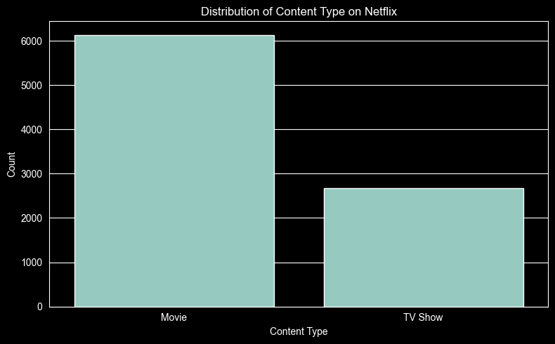

```python
plt.figure(figsize=(8, 5))
sns.countplot(data=df_clean, x='type')
plt.title('Distribution of Content Type on Netflix')
plt.xlabel('Content Type')
plt.ylabel('Count')
plt.tight_layout()
plt.show()
```

### Observation

Movies clearly dominate the Netflix catalog compared to TV Shows.

### Interpretation

This confirms that Netflix’s library is still more movie-heavy. However, this does not yet tell us whether TV Shows are becoming more important in recent years, which will be explored later using time-based analysis.

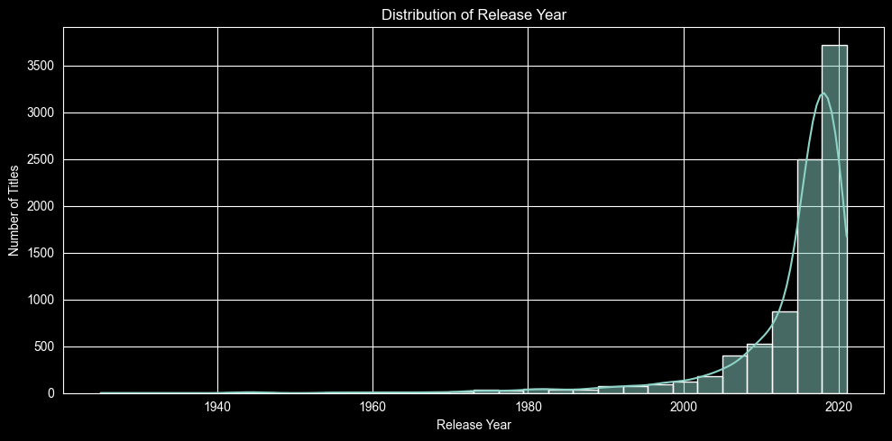

```python
# Release Year Distribution
plt.figure(figsize=(10, 5))
sns.histplot(df_clean['release_year'], bins=30, kde=True)
plt.title('Distribution of Release Year')
plt.xlabel('Release Year')
plt.ylabel('Number of Titles')
plt.tight_layout()
plt.show()
```

### Observation

Most titles in the dataset are concentrated in relatively recent years, with much lower representation for older content.

### Interpretation

Netflix appears to rely heavily on modern content, which aligns with changing audience preferences and the platform’s focus on keeping its catalog fresh and relevant.

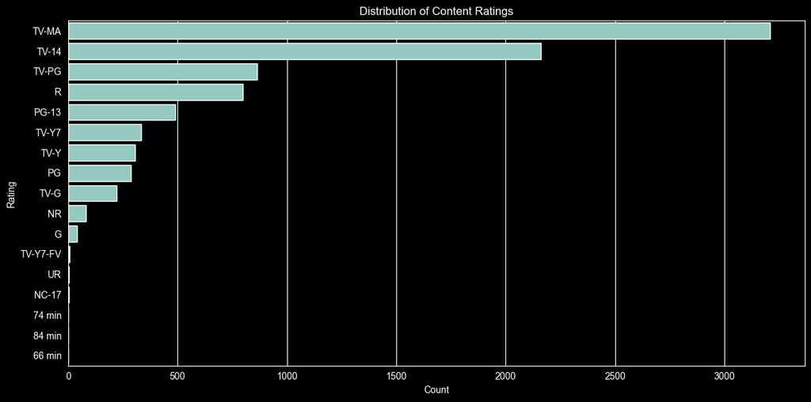

```python
# Content Rating Distribution
plt.figure(figsize=(12, 6))
sns.countplot(data=df_clean, y='rating', order=df_clean['rating'].value_counts().index)
plt.title('Distribution of Content Ratings')
plt.xlabel('Count')
plt.ylabel('Rating')
plt.tight_layout()
plt.show()
```

### Observation

Ratings such as TV-MA and TV-14 appear most frequently in the dataset.

### Interpretation

This suggests that Netflix’s catalog is strongly oriented toward teen and adult audiences, though it still includes family-friendly and children’s content.

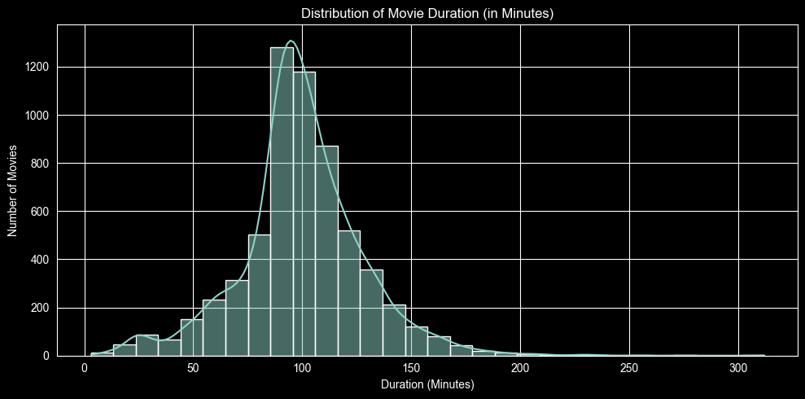

```python
# Movie Duration Distribution
movie_data = df_clean[df_clean['duration_type'] == 'Minutes']

plt.figure(figsize=(10, 5))
sns.histplot(movie_data['duration_int'].dropna(), bins=30, kde=True)
plt.title('Distribution of Movie Duration (in Minutes)')
plt.xlabel('Duration (Minutes)')
plt.ylabel('Number of Movies')
plt.tight_layout()
plt.show()
```

### Observation

Most movies appear to cluster around standard feature-film lengths, with fewer very short or very long titles.

### Interpretation

Netflix’s movie catalog largely follows conventional movie duration norms, which may reflect audience preferences for standard-length films.

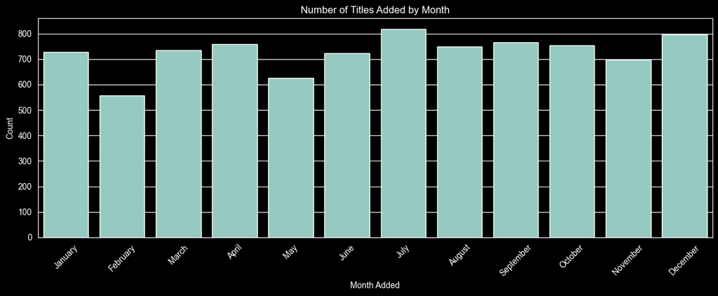

```python
# Titles Added by Month
month_order = ['January', 'February', 'March', 'April', 'May', 'June',
               'July', 'August', 'September', 'October', 'November', 'December']

plt.figure(figsize=(12, 5))
sns.countplot(data=df_clean, x='month_added', order=month_order)
plt.title('Number of Titles Added by Month')
plt.xlabel('Month Added')
plt.ylabel('Count')
plt.xticks(rotation=45)
plt.tight_layout()
plt.show()
```

### Observation

The number of titles added varies across months, indicating that Netflix does not add content uniformly throughout the year.

### Interpretation

This may help identify stronger content release windows and can support decisions around the timing of new title launches.

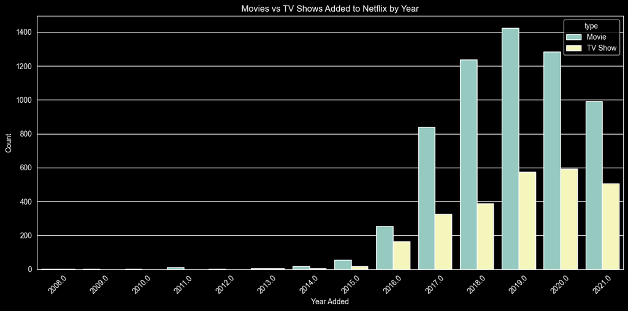

```python
# Bivariate Visual Analysis
# Movies vs TV Shows Added Over Time
plt.figure(figsize=(12, 6))
sns.countplot(data=df_clean, x='year_added', hue='type', order=sorted(df_clean['year_added'].dropna().unique()))
plt.title('Movies vs TV Shows Added to Netflix by Year')
plt.xlabel('Year Added')
plt.ylabel('Count')
plt.xticks(rotation=45)
plt.tight_layout()
plt.show()
```

### Observation

This plot shows how the number of Movies and TV Shows added to Netflix has changed over time.

### Interpretation

This helps identify whether Netflix has increased its focus on TV Shows in more recent years, which is a key part of the business problem.

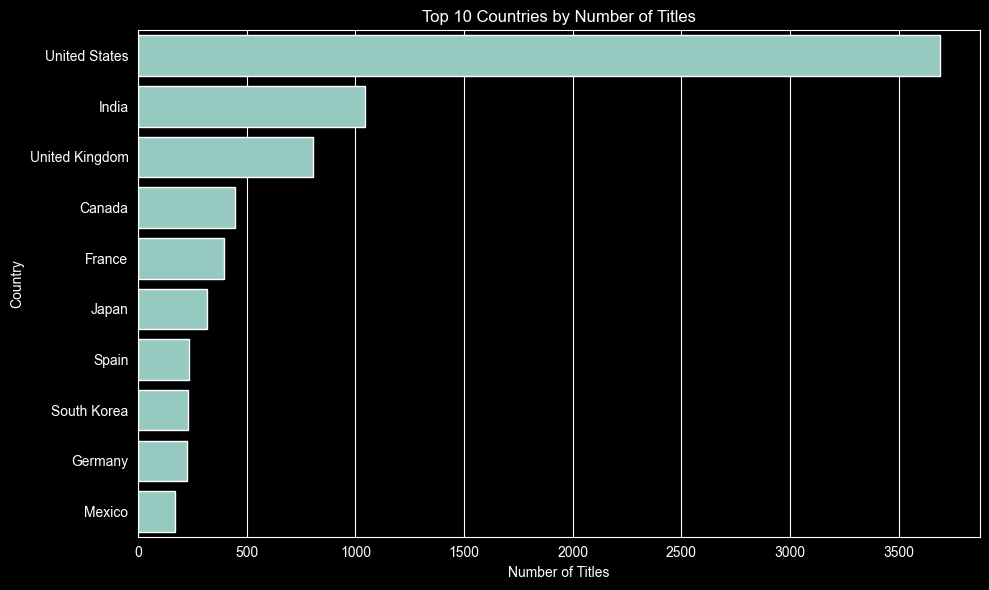

```python
# Top 10 Countries After Exploding
top_10_countries = df_country['country'].value_counts().head(10)

plt.figure(figsize=(10, 6))
sns.barplot(x=top_10_countries.values, y=top_10_countries.index)
plt.title('Top 10 Countries by Number of Titles')
plt.xlabel('Number of Titles')
plt.ylabel('Country')
plt.tight_layout()
plt.show()
```

### Observation

A small number of countries contribute a large share of Netflix’s available content.

### Interpretation

This suggests that Netflix’s catalog is concentrated in a few major production markets, which can guide both growth strategy and localization decisions.

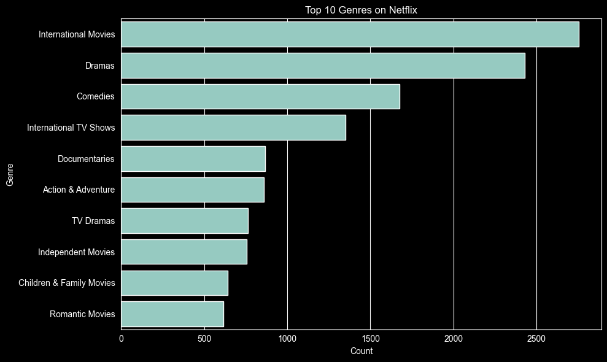

```python
# Top 10 Genres After Exploding
top_10_genres = df_genre['listed_in'].value_counts().head(10)

plt.figure(figsize=(10, 6))
sns.barplot(x=top_10_genres.values, y=top_10_genres.index)
plt.title('Top 10 Genres on Netflix')
plt.xlabel('Count')
plt.ylabel('Genre')
plt.tight_layout()
plt.show()
```

### Observation

Genres such as International Movies, Dramas, and Comedies appear very frequently in the catalog.

### Interpretation

This indicates that Netflix relies strongly on broad-appeal genres and international content categories, which are likely central to its global growth model.

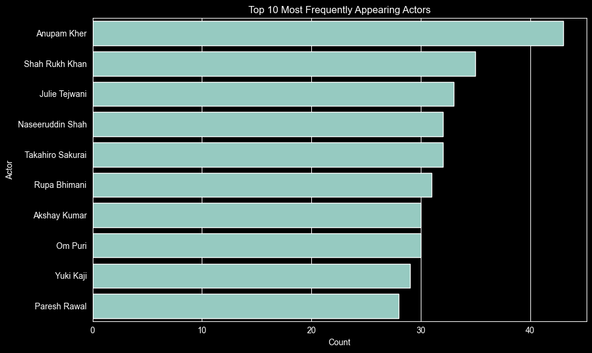

```python
# Top 10 Actors After Exploding
top_10_actors = df_cast['cast'].value_counts().head(10)

plt.figure(figsize=(10, 6))
sns.barplot(x=top_10_actors.values, y=top_10_actors.index)
plt.title('Top 10 Most Frequently Appearing Actors')
plt.xlabel('Count')
plt.ylabel('Actor')
plt.tight_layout()
plt.show()
```

### Observation

A few actors appear repeatedly across Netflix titles.

### Interpretation

This may reflect strong representation from specific film industries and recurring popularity of certain actors, especially in countries contributing a large number of titles.

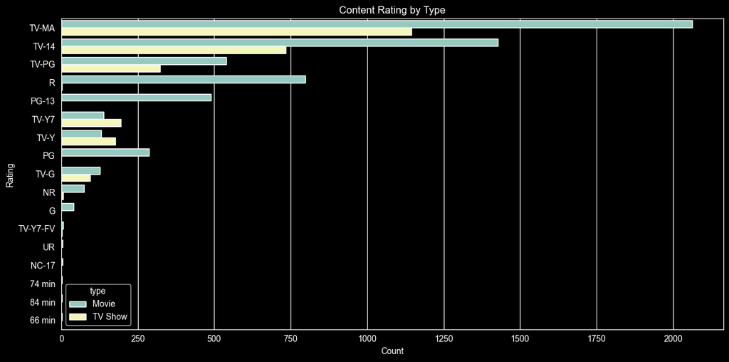

```python
# Rating By Content Type
plt.figure(figsize=(12, 6))
sns.countplot(data=df_clean, y='rating', hue='type', order=df_clean['rating'].value_counts().index)
plt.title('Content Rating by Type')
plt.xlabel('Count')
plt.ylabel('Rating')
plt.tight_layout()
plt.show()
```

### Observation

The rating mix differs across Movies and TV Shows.

### Interpretation

This helps identify whether Netflix uses different audience targeting strategies for movies versus serialized content.

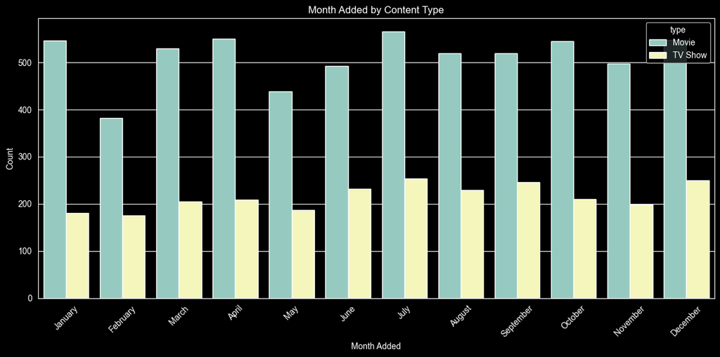

```python
# Month Added by Content Type
plt.figure(figsize=(12, 6))
sns.countplot(data=df_clean, x='month_added', hue='type', order=month_order)
plt.title('Month Added by Content Type')
plt.xlabel('Month Added')
plt.ylabel('Count')
plt.xticks(rotation=45)
plt.tight_layout()
plt.show()
```

### Observation

This plot shows how the timing of additions varies for Movies and TV Shows across the calendar year.

### Interpretation

This may help identify stronger months for TV Show launches and whether Netflix follows a different seasonal pattern for movies and shows.

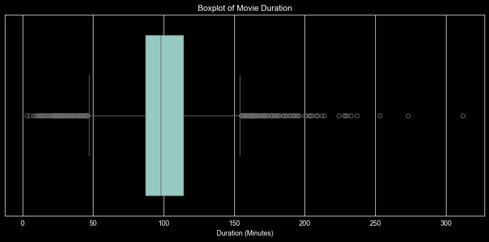

```python
# Outlier Check/Spread Analysis
# Movie Distribution BoxPlot
plt.figure(figsize=(10, 5))
sns.boxplot(x=movie_data['duration_int'].dropna())
plt.title('Boxplot of Movie Duration')
plt.xlabel('Duration (Minutes)')
plt.tight_layout()
plt.show()
```

### Observation

The boxplot helps identify the spread of movie durations and reveals whether extreme-duration outliers are present.

### Interpretation

A few very short or very long movies may exist, but most titles are concentrated within a standard runtime range.

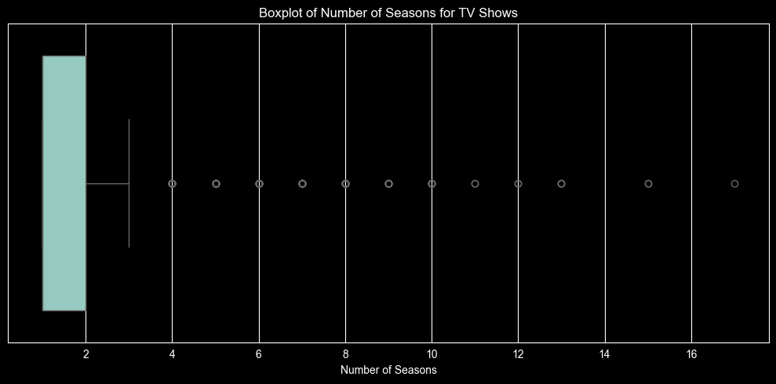

```python
# TV Show Season Boxplot
tv_data = df_clean[df_clean['duration_type'] == 'Seasons']

plt.figure(figsize=(10, 5))
sns.boxplot(x=tv_data['duration_int'].dropna())
plt.title('Boxplot of Number of Seasons for TV Shows')
plt.xlabel('Number of Seasons')
plt.tight_layout()
plt.show()
```

### Observation

Most TV Shows appear to have a relatively low number of seasons, while a few titles extend much longer.

### Interpretation

This suggests that Netflix’s TV catalog is dominated by short-run series, which may indicate a preference for limited-series formats or lower renewal risk.

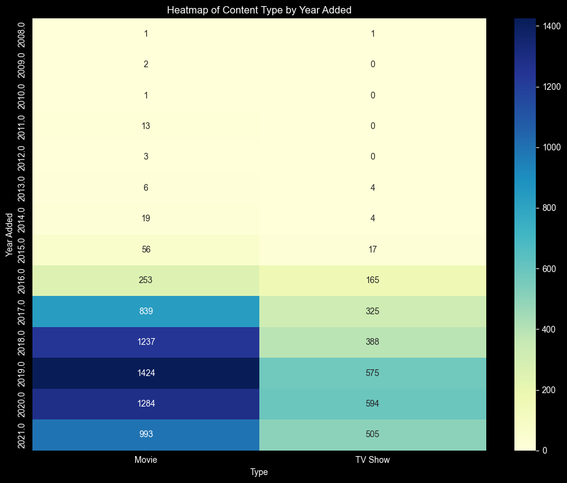

```python
# Heatmap of the content type by year added
content_year = pd.crosstab(df_clean['year_added'], df_clean['type'])

plt.figure(figsize=(10, 8))
sns.heatmap(content_year, annot=True, fmt='g', cmap='YlGnBu')
plt.title('Heatmap of Content Type by Year Added')
plt.xlabel('Type')
plt.ylabel('Year Added')
plt.tight_layout()
plt.show()
```

### Observation

The heatmap provides a compact view of how Movies and TV Shows were added across different years.

### Interpretation

This makes it easier to identify years in which Netflix accelerated content expansion and whether the growth pattern differed between movies and TV shows.

## Missing Value and Outlier Check

In this section, the goal is to examine whether missing values and outliers could materially affect the quality of the analysis.

Since missing value treatment is optional in this case study, the focus will be on:

- identifying the remaining missing values after preprocessing
- understanding which columns are affected the most
- checking whether numerical variables contain extreme values
- deciding whether any treatment is required before drawing business conclusions

This step is important because missing values and unusual observations can sometimes distort patterns, especially in business-facing analysis.

```python
# Missing values after preprocessing
missing_counts = df_clean.isnull().sum()
missing_counts[missing_counts > 0].sort_values(ascending=False)
```

```
director         2634
country           831
cast              825
date_added         98
year_added         98
month_added        98
rating              4
duration            3
duration_int        3
duration_type       3
dtype: int64
```

```python
# Missing value percentage after preprocessing
missing_percent = round((df_clean.isnull().sum() / len(df_clean)) * 100, 2)
missing_percent[missing_percent > 0].sort_values(ascending=False)
```

```
director         29.91
country           9.44
cast              9.37
date_added        1.11
year_added        1.11
month_added       1.11
rating            0.05
duration          0.03
duration_int      0.03
duration_type     0.03
dtype: float64
```

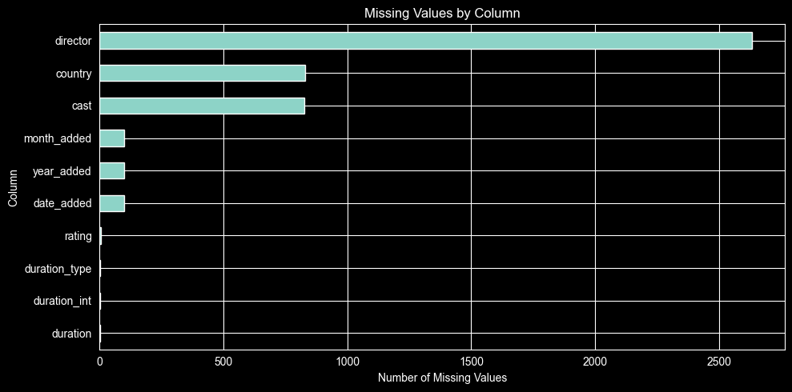

```python
# Visualize missing values count
missing_plot = missing_counts[missing_counts > 0].sort_values(ascending=True)

plt.figure(figsize=(10, 5))
missing_plot.plot(kind='barh')
plt.title('Missing Values by Column')
plt.xlabel('Number of Missing Values')
plt.ylabel('Column')
plt.tight_layout()
plt.show()
```

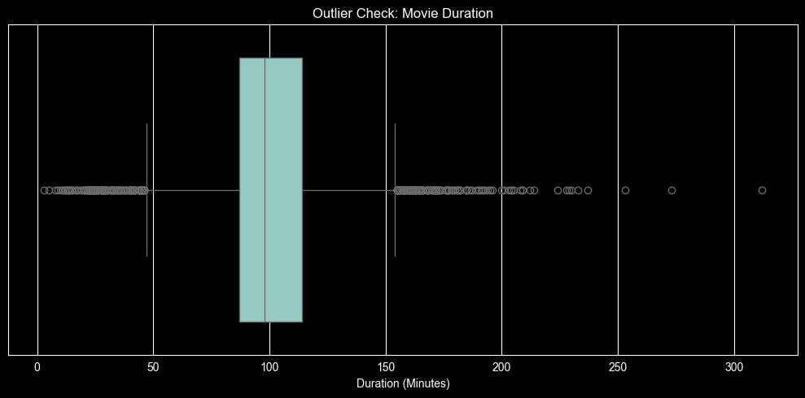

```python
# Boxplot for movie duration outliers
plt.figure(figsize=(10, 5))
sns.boxplot(x=movie_data['duration_int'].dropna())
plt.title('Outlier Check: Movie Duration')
plt.xlabel('Duration (Minutes)')
plt.tight_layout()
plt.show()
```

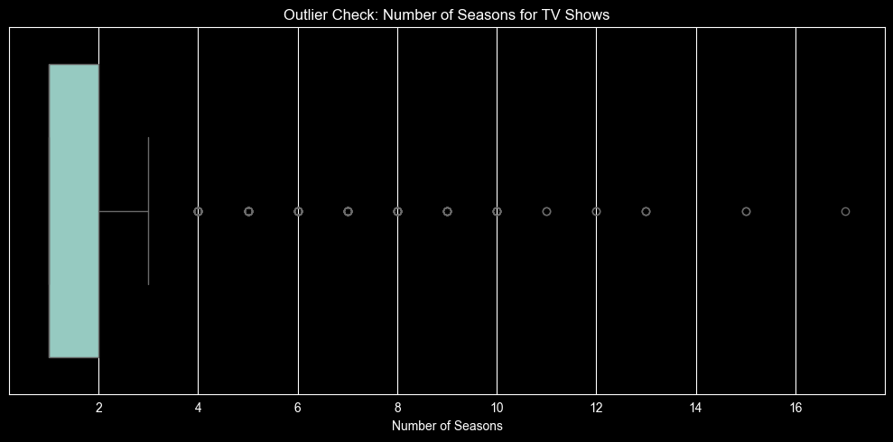

```python
# Boxplot for TV show season outliers
plt.figure(figsize=(10, 5))
sns.boxplot(x=tv_data['duration_int'].dropna())
plt.title('Outlier Check: Number of Seasons for TV Shows')
plt.xlabel('Number of Seasons')
plt.tight_layout()
plt.show()
```

```python
# Numerical summaries for outlier inspection
print("Movie duration summary:")
print(movie_data['duration_int'].describe())

print("\nTV show seasons summary:")
print(tv_data['duration_int'].describe())
```

```
Movie duration summary:
count    6128.000000
mean       99.577187
std        28.290593
min         3.000000
25%        87.000000
50%        98.000000
75%       114.000000
max       312.000000
Name: duration_int, dtype: float64

TV show seasons summary:
count    2676.000000
mean        1.764948
std         1.582752
min         1.000000
25%         1.000000
50%         1.000000
75%         2.000000
max        17.000000
Name: duration_int, dtype: float64
```

```python
# Check unusually long movies
movie_data[movie_data['duration_int'] > 180][['title', 'duration_int', 'country', 'release_year']].sort_values(by='duration_int', ascending=False).head(10)
```

|  | title | duration_int | country | release_year |
| --- | --- | --- | --- | --- |
| 4253 | Black Mirror: Bandersnatch | 312.0 | United States | 2018 |
| 717 | Headspace: Unwind Your Mind | 273.0 | NaN | 2021 |
| 2491 | The School of Mischief | 253.0 | Egypt | 1973 |
| 2487 | No Longer kids | 237.0 | Egypt | 1979 |
| 2484 | Lock Your Girls In | 233.0 | NaN | 1982 |
| 2488 | Raya and Sakina | 230.0 | NaN | 1984 |
| 166 | Once Upon a Time in America | 229.0 | Italy, United States | 1984 |
| 7932 | Sangam | 228.0 | India | 1964 |
| 1019 | Lagaan | 224.0 | India, United Kingdom | 2001 |
| 4573 | Jodhaa Akbar | 214.0 | India | 2008 |

```python
# Check unusually long-running TV shows
tv_data[tv_data['duration_int'] > 5][['title', 'duration_int', 'country', 'release_year']].sort_values(by='duration_int', ascending=False).head(10)
```

|  | title | duration_int | country | release_year |
| --- | --- | --- | --- | --- |
| 548 | Grey's Anatomy | 17.0 | United States | 2020 |
| 2423 | Supernatural | 15.0 | United States, Canada | 2019 |
| 4798 | NCIS | 15.0 | United States | 2017 |
| 1354 | Heartland | 13.0 | Canada | 2019 |
| 4220 | COMEDIANS of the world | 13.0 | United States | 2019 |
| 7847 | Red vs. Blue | 13.0 | United States | 2015 |
| 5412 | Criminal Minds | 12.0 | United States, Canada | 2017 |
| 4964 | Trailer Park Boys | 12.0 | Canada | 2018 |
| 6456 | Cheers | 11.0 | United States | 1992 |
| 6795 | Frasier | 11.0 | United States | 2003 |

## Observations from Missing Value and Outlier Check

### 1. Missing value analysis

The missing value check shows that missing data is concentrated mainly in metadata-related columns rather than the core structural columns of the dataset.

#### Highest missing columns

- **director** → 2634 missing values (**29.91%**)
- **country** → 831 missing values (**9.44%**)
- **cast** → 825 missing values (**9.37%**)

#### Smaller missing columns

- **date_added** → 98 missing values (**1.11%**)
- **year_added** → 98 missing values (**1.11%**)
- **month_added** → 98 missing values (**1.11%**)
- **rating** → 4 missing values (**0.05%**)
- **duration** → 3 missing values (**0.03%**)
- **duration_int** → 3 missing values (**0.03%**)
- **duration_type** → 3 missing values (**0.03%**)

### Interpretation of missing values

The missing values are mostly concentrated in descriptive metadata such as director, cast, and country. This means the dataset is still strong enough for business analysis because key variables such as:

- `type`
- `title`
- `release_year`

remain complete.

However, the missing values in `director`, `cast`, and `country` may slightly reduce the completeness of people-level or geography-level insights.

The missing values in `year_added` and `month_added` are expected because those columns were derived from `date_added`, so any missingness in `date_added` naturally carries forward.

### 2. Outlier analysis for movie duration

The boxplot and numerical summary show that movie duration has a clear central concentration, but also contains a number of extreme high-duration outliers.

#### Movie duration summary

- **Count:** 6128
- **Mean:** 99.58 minutes
- **Median:** 98 minutes
- **25th percentile:** 87 minutes
- **75th percentile:** 114 minutes
- **Maximum:** 312 minutes

This indicates that most Netflix movies fall within a standard feature-length range, but a few titles are much longer than usual.

#### Examples of unusually long movies

Some extreme cases include:

- **Black Mirror: Bandersnatch** → 312 minutes
- **Headspace: Unwind Your Mind** → 273 minutes
- **The School of Mischief** → 253 minutes
- **No Longer kids** → 237 minutes
- **Lock Your Girls In** → 233 minutes

### Interpretation

These values do not appear to be obvious data errors. Instead, they likely represent:

- interactive specials
- anthology content
- older long-format films
- special editions or unusually long productions

So, while these are statistical outliers, they are still **valid content entries** and should not be removed without a strong reason.

### 3. Outlier analysis for TV show seasons

The boxplot and summary for TV shows show that the catalog is heavily concentrated around short-run shows, with a few long-running series appearing as outliers.

#### TV show season summary

- **Count:** 2676
- **Mean:** 1.76 seasons
- **Median:** 1 season
- **25th percentile:** 1 season
- **75th percentile:** 2 seasons
- **Maximum:** 17 seasons

This tells us that most Netflix TV shows are short in length, and one-season series are especially common.

#### Examples of long-running shows

Some of the longest-running series include:

- **Grey’s Anatomy** → 17 seasons
- **Supernatural** → 15 seasons
- **NCIS** → 15 seasons
- **Heartland** → 13 seasons
- **COMEDIANS of the world** → 13 seasons
- **Criminal Minds** → 12 seasons
- **Trailer Park Boys** → 12 seasons
- **Cheers** → 11 seasons
- **Frasier** → 11 seasons

### Interpretation

These are not likely to be invalid values. Instead, they represent genuine long-running series, which can be strategically important because such shows often support:

- audience retention
- binge-watching behavior
- long-term engagement

### 4. Treatment decision

No aggressive missing value treatment or outlier removal is applied in this case study.

This is a reasonable choice because:

- the missing values are mainly in metadata fields
- the outliers appear plausible and meaningful
- the analysis is exploratory and business-oriented rather than predictive-model-focused

Removing these values might actually reduce business meaning rather than improve it.

### 5. Business takeaway

From a business perspective, this section suggests that:

- Netflix’s catalog metadata is incomplete in some areas, especially director and cast information
- the movie catalog mostly follows standard runtime expectations, with a few special long-format exceptions
- the TV catalog is dominated by short-run series, but also includes a smaller set of long-running franchises

This diversity in content length is likely useful for serving different viewing preferences, from quick movie sessions to long-term serialized engagement.

## Business Insights

Based on the non-graphical analysis, visual analysis, and missing value review, several important business insights emerge from Netflix’s content catalog.

These insights aim to answer the central business question of this case study:

**What type of shows or movies should Netflix focus on producing, and how can the platform grow its business across different countries?**

### 1. Netflix’s catalog is still dominated by movies

The analysis shows that nearly **70% of the catalog consists of movies**, while TV shows account for about **30%**.

#### Business meaning

This suggests that movies remain the largest content category on the platform and continue to form the backbone of Netflix’s library.

#### Strategic implication

Netflix should continue investing in movies, but not uniformly. Instead, it should focus on movie categories that already show strong platform presence and broad audience appeal, especially:

- dramas
- comedies
- international movies
- documentaries
- action and adventure titles

### 2. Netflix relies heavily on relatively recent content

The release year analysis shows that the catalog is concentrated in recent years, with a median release year of **2017** and a strong concentration in the last decade.

#### Business meaning

Netflix appears to compete strongly on freshness and relevance rather than relying mainly on old back-catalog content.

#### Strategic implication

This suggests that users likely expect contemporary content. Netflix should continue prioritizing:

- recent releases
- new originals
- modern storytelling formats
- faster refresh cycles in high-demand genres

### 3. Mature audience content is a major strength of the platform

Ratings such as **TV-MA** and **TV-14** dominate the dataset.

#### Business meaning

A large share of Netflix’s library is targeted toward teen and adult audiences, which likely reflects stronger engagement in these segments.

#### Strategic implication

Netflix should continue strengthening mature and youth-adult content categories, especially in genres like:

- drama
- thriller
- crime
- action
- dark comedy
- documentary

At the same time, the platform should maintain a balanced pipeline of family-friendly content to avoid becoming too narrow in audience focus.

### 5. India appears to be a highly important content market

#### Business meaning

India is not just a large audience market; it is also a major content supply market within Netflix’s catalog.

#### Strategic implication

Netflix should continue investing in India through:

- original films
- limited series
- regional-language content
- partnerships with well-known Indian actors, writers, and directors

India appears to offer both scale and cultural diversity, making it one of the most strategically valuable markets for content expansion.

### 6. Short-run TV shows dominate the catalog

The season analysis shows that most TV shows have only **1 or 2 seasons**, while a smaller number run much longer.

#### Business meaning

Netflix’s catalog is heavily weighted toward short-run or limited-series style content rather than extremely long franchise-heavy television.

#### Strategic implication

This may reflect a deliberate strategy:

- lower renewal risk
- faster experimentation
- easier audience entry
- shorter production commitment

Netflix should continue using short-run series as a flexible format for testing genres, regions, and audience segments. At the same time, when a show performs strongly, it may be worth extending it into a long-term franchise because long-running series can improve retention and repeat viewing.

### 7. Standard-length movies appear to be the norm

The movie duration analysis shows that most films fall into a conventional runtime range, with a median close to **98 minutes**.

#### Business meaning

Netflix’s catalog mostly aligns with normal feature-film viewing behavior. Most users are likely being served content that fits standard entertainment time expectations.

#### Strategic implication

Netflix should continue producing and acquiring movies in the standard-length range because that appears to be the most commercially practical format. Long-duration titles should be used selectively for:

- special projects
- prestige content
- event-driven releases
- anthology or experimental formats

### 8. Metadata gaps may slightly weaken some people-level or country-level analysis

The missing value analysis shows substantial missingness in:

- `director`
- `cast`
- `country`

#### Business meaning

Some business conclusions related to creator ecosystems, actor frequency, or geography may slightly undercount certain titles.

#### Strategic implication

Netflix could improve internal metadata consistency because stronger metadata quality would support:

- better recommendation systems
- better audience segmentation
- stronger production intelligence
- more accurate talent and regional analysis

### 9. Netflix appears to be balancing breadth with localization

The platform contains:

- globally popular genres such as dramas and comedies
- regionally important content markets
- a strong mix of movies, TV shows, documentaries, and international categories

#### Business meaning

Netflix is not relying on a single content formula. Instead, it appears to be balancing broad-appeal global content with region-specific offerings.

#### Strategic implication

This suggests that Netflix’s strongest growth model is likely:

- globally scalable genres
- locally resonant storytelling
- content diversification by geography and audience type

### Overall Insight Summary

Overall, the analysis suggests that Netflix’s content strategy is strongest when it combines:

- a movie-heavy catalog base
- strong mature-audience offerings
- global and international content expansion
- short-run TV show experimentation
- selective long-running franchises
- strong investment in major international markets such as India and other high-output regions

These insights form the basis for the final recommendations.

## Recommendations

### 1. Continue investing in movies, but focus on high-performing genres

Since movies make up the majority of the catalog, Netflix should continue using films as a core content pillar. However, investment should be more selective and concentrated in genres that already show strong representation and broad appeal, especially:

- dramas
- comedies
- international movies
- documentaries
- action and adventure

These categories appear to form a strong base for audience reach and engagement.

### 2. Expand international content production aggressively

International Movies and International TV Shows are among the strongest categories in the dataset, and multiple non-US countries contribute significantly to the catalog.

Netflix should continue increasing investment in:

- local originals
- multilingual content
- region-specific storytelling
- international licensing partnerships

This is especially relevant in markets such as:

- India
- United Kingdom
- Japan
- South Korea
- Spain
- France

These regions appear to offer strong opportunities for both audience growth and content supply.

### 3. Strengthen content strategy in India

India stands out as one of the most important markets in the dataset, both in country-level representation and in repeated appearance of major actors.

Netflix should deepen its India strategy through:

- Hindi originals
- regional-language films and series
- partnerships with top Indian actors, directors, and creators
- strong promotion of Indian content to both domestic and global audiences

India appears to be one of the most scalable markets for future content expansion.

### 4. Keep building for mature audiences, while preserving catalog balance

The dominance of TV-MA and TV-14 suggests that Netflix’s strongest content base is in teen and adult-oriented categories.

Netflix should continue building in mature-content segments such as:

- crime
- thriller
- drama
- dark comedy
- serious documentaries

However, the company should also maintain enough:

- family content
- children’s programming
- PG and PG-13 catalog depth

This is important to avoid overconcentration in one audience segment.

### 5. Use short-run TV shows as a low-risk experimentation model

Most TV shows in the catalog have only 1 or 2 seasons. This suggests that shorter series may already be functioning as a flexible format for testing content ideas.

Netflix should continue using short-run shows to:

- test new genres
- test new markets
- test audience response
- reduce renewal risk
- introduce fresh creators and talent

This strategy is likely efficient for discovering successful concepts before committing to long-running productions.

### 6. Extend selected hits into long-running franchises

Although most TV shows are short, the dataset also includes a small set of long-running series.

This suggests that long-running content still has strategic value when a title performs strongly.

Netflix should identify high-performing series and selectively extend them into:

- multi-season franchises
- spin-offs
- universe-based storytelling
- recurring audience-retention formats

This can improve long-term engagement and subscription retention.

### 7. Maintain standard-length movie formats for mainstream releases

Most movies are clustered around conventional feature-length durations.

Netflix should continue prioritizing standard-length films because they are likely easier for audiences to consume and fit more naturally into everyday viewing behavior.

Very long films should be reserved for:

- event titles
- prestige projects
- special releases
- experimental formats

### 8. Improve metadata quality across director, cast, and country fields

The missing-value analysis shows that some important metadata fields are incomplete, especially:

- director
- cast
- country

Netflix should improve metadata consistency because stronger metadata would support:

- better content recommendations
- more accurate audience segmentation
- stronger regional strategy
- better talent and creator analysis
- improved internal decision-making

### 9. Balance global scale with local relevance

The overall pattern of the catalog suggests that Netflix performs best when it combines:

- globally popular content categories
- strong international expansion
- local storytelling adapted to specific markets

Netflix should continue growing with a dual strategy:

- scale content globally where possible
- localize content deeply where necessary

This balance is likely one of the company’s strongest long-term competitive advantages.

## Conclusion

This case study explored Netflix’s content catalog using data exploration, preprocessing, non-graphical analysis, visual analysis, and business interpretation.

The analysis showed that Netflix’s catalog is dominated by movies, strongly concentrated in recent years, and heavily oriented toward mature audience content. It also revealed that international content plays a major role in the platform’s library, with countries such as the United States, India, and the United Kingdom making major contributions.

Genre-level analysis showed strong representation of International Movies, Dramas, Comedies, and International TV Shows, while duration analysis showed that most movies follow standard feature-film lengths and most TV shows are short-run series with one or two seasons.

From a business point of view, the results suggest that Netflix should continue:

- investing in high-performing movie genres
- expanding international and multilingual content
- strengthening key markets such as India
- using short-run TV shows for experimentation
- extending selected successful shows into long-running franchises
- improving metadata quality for better strategic decision-making

Overall, the findings suggest that Netflix’s growth strategy is strongest when it combines global scale, local relevance, broad genre coverage, and flexible content formats.